# Part 1: Explanatory Data Analysis & Data Presentation

## Data Import and first Inspection

```python
import pandas as pd
import matplotlib.pyplot as plt
import numpy as np
pd.options.display.max_columns = 30
pd.options.display.float_format = '{:.2f}'.format
```

```python
df = pd.read_csv("movies_complete.csv", parse_dates= ["release_date"])
```

```python
df.head()
```

|  | id | title | tagline | release_date | genres | belongs_to_collection | original_language | budget_musd | revenue_musd | production_companies | production_countries | vote_count | vote_average | popularity | runtime | overview | spoken_languages | poster_path | cast | cast_size | crew_size | director |
| --- | --- | --- | --- | --- | --- | --- | --- | --- | --- | --- | --- | --- | --- | --- | --- | --- | --- | --- | --- | --- | --- | --- |
| 0 | 862 | Toy Story | NaN | 1995-10-30 | Animation\|Comedy\|Family | Toy Story Collection | en | 30.00 | 373.55 | Pixar Animation Studios | United States of America | 5415.00 | 7.70 | 21.95 | 81.00 | Led by Woody, Andy's toys live happily in his ... | English | <img src='http://image.tmdb.org/t/p/w185//uXDf... | Tom Hanks\|Tim Allen\|Don Rickles\|Jim Varney\|Wal... | 13 | 106 | John Lasseter |
| 1 | 8844 | Jumanji | Roll the dice and unleash the excitement! | 1995-12-15 | Adventure\|Fantasy\|Family | NaN | en | 65.00 | 262.80 | TriStar Pictures\|Teitler Film\|Interscope Commu... | United States of America | 2413.00 | 6.90 | 17.02 | 104.00 | When siblings Judy and Peter discover an encha... | English\|Français | <img src='http://image.tmdb.org/t/p/w185//vgpX... | Robin Williams\|Jonathan Hyde\|Kirsten Dunst\|Bra... | 26 | 16 | Joe Johnston |
| 2 | 15602 | Grumpier Old Men | Still Yelling. Still Fighting. Still Ready for... | 1995-12-22 | Romance\|Comedy | Grumpy Old Men Collection | en | NaN | NaN | Warner Bros.\|Lancaster Gate | United States of America | 92.00 | 6.50 | 11.71 | 101.00 | A family wedding reignites the ancient feud be... | English | <img src='http://image.tmdb.org/t/p/w185//1FSX... | Walter Matthau\|Jack Lemmon\|Ann-Margret\|Sophia ... | 7 | 4 | Howard Deutch |
| 3 | 31357 | Waiting to Exhale | Friends are the people who let you be yourself... | 1995-12-22 | Comedy\|Drama\|Romance | NaN | en | 16.00 | 81.45 | Twentieth Century Fox Film Corporation | United States of America | 34.00 | 6.10 | 3.86 | 127.00 | Cheated on, mistreated and stepped on, the wom... | English | <img src='http://image.tmdb.org/t/p/w185//4wjG... | Whitney Houston\|Angela Bassett\|Loretta Devine\|... | 10 | 10 | Forest Whitaker |
| 4 | 11862 | Father of the Bride Part II | Just When His World Is Back To Normal... He's ... | 1995-02-10 | Comedy | Father of the Bride Collection | en | NaN | 76.58 | Sandollar Productions\|Touchstone Pictures | United States of America | 173.00 | 5.70 | 8.39 | 106.00 | Just when George Banks has recovered from his ... | English | <img src='http://image.tmdb.org/t/p/w185//lf9R... | Steve Martin\|Diane Keaton\|Martin Short\|Kimberl... | 12 | 7 | Charles Shyer |

```python
df.info()
```

```
<class 'pandas.core.frame.DataFrame'>
RangeIndex: 44691 entries, 0 to 44690
Data columns (total 22 columns):
 #   Column                 Non-Null Count  Dtype
---  ------                 --------------  -----
 0   id                     44691 non-null  int64
 1   title                  44691 non-null  object
 2   tagline                20284 non-null  object
 3   release_date           44657 non-null  datetime64[ns]
 4   genres                 42586 non-null  object
 5   belongs_to_collection  4463 non-null   object
 6   original_language      44681 non-null  object
 7   budget_musd            8854 non-null   float64
 8   revenue_musd           7385 non-null   float64
 9   production_companies   33356 non-null  object
 10  production_countries   38835 non-null  object
 11  vote_count             44691 non-null  float64
 12  vote_average           42077 non-null  float64
 13  popularity             44691 non-null  float64
 14  runtime                43179 non-null  float64
 15  overview               43740 non-null  object
 16  spoken_languages       41094 non-null  object
 17  poster_path            44467 non-null  object
 18  cast                   42502 non-null  object
 19  cast_size              44691 non-null  int64
 20  crew_size              44691 non-null  int64
 21  director               43960 non-null  object
dtypes: datetime64[ns](1), float64(6), int64(3), object(12)
memory usage: 7.5+ MB
```

**Features**:

- **id:** The ID of the movie (clear/unique identifier).
- **title:** The Official Title of the movie.
- **tagline:** The tagline of the movie.
- **release_date:** Theatrical Release Date of the movie.
- **genres:** Genres associated with the movie.
- **belongs_to_collection:** Gives information on the movie series/franchise the particular film belongs to.
- **original_language:** The language in which the movie was originally shot in.
- **budget_musd:** The budget of the movie in million dollars.
- **revenue_musd:** The total revenue of the movie in million dollars.
- **production_companies:** Production companies involved with the making of the movie.
- **production_countries:** Countries where the movie was shot/produced in.
- **vote_count:** The number of votes by users, as counted by TMDB.
- **vote_average:** The average rating of the movie.
- **popularity:** The Popularity Score assigned by TMDB.
- **runtime:** The runtime of the movie in minutes.
- **overview:** A brief blurb of the movie.
- **spoken_languages:** Spoken languages in the film.
- **poster_path:** The URL of the poster image.
- **cast:** (Main) Actors appearing in the movie.
- **cast_size:** number of Actors appearing in the movie.
- **director:** Director of the movie.
- **crew_size:** Size of the film crew (incl. director, excl. actors).

```python
df.genres[1]
```

```
'Adventure|Fantasy|Family'
```

```python
df.cast[1]
```

```
'Robin Williams|Jonathan Hyde|Kirsten Dunst|Bradley Pierce|Bonnie Hunt|Bebe Neuwirth|David Alan Grier|Patricia Clarkson|Adam Hann-Byrd|Laura Bell Bundy|James Handy|Gillian Barber|Brandon Obray|Cyrus Thiedeke|Gary Joseph Thorup|Leonard Zola|Lloyd Berry|Malcolm Stewart|Annabel Kershaw|Darryl Henriques…
```

```python
df.describe()
```

|  | id | budget_musd | revenue_musd | vote_count | vote_average | popularity | runtime | cast_size | crew_size |
| --- | --- | --- | --- | --- | --- | --- | --- | --- | --- |
| count | 44691.00 | 8854.00 | 7385.00 | 44691.00 | 42077.00 | 44691.00 | 43179.00 | 44691.00 | 44691.00 |
| mean | 107186.24 | 21.67 | 68.97 | 111.65 | 6.00 | 2.96 | 97.57 | 12.48 | 10.31 |
| std | 111806.36 | 34.36 | 146.61 | 495.32 | 1.28 | 6.04 | 34.65 | 12.12 | 15.89 |
| min | 2.00 | 0.00 | 0.00 | 0.00 | 0.00 | 0.00 | 1.00 | 0.00 | 0.00 |
| 25% | 26033.50 | 2.00 | 2.41 | 3.00 | 5.30 | 0.40 | 86.00 | 6.00 | 2.00 |
| 50% | 59110.00 | 8.20 | 16.87 | 10.00 | 6.10 | 1.15 | 95.00 | 10.00 | 6.00 |
| 75% | 154251.00 | 25.00 | 67.64 | 35.00 | 6.80 | 3.77 | 107.00 | 15.00 | 12.00 |
| max | 469172.00 | 380.00 | 2787.97 | 14075.00 | 10.00 | 547.49 | 1256.00 | 313.00 | 435.00 |

```python
plt.style.use("ggplot")
```

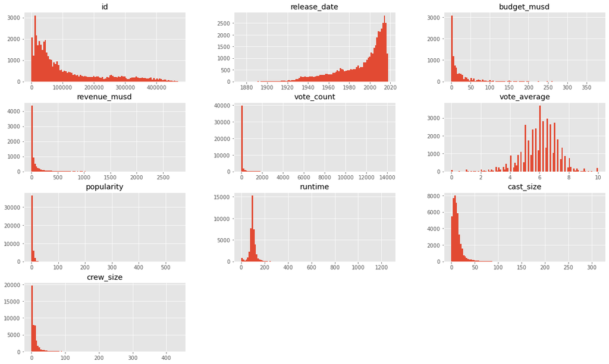

```python
df.hist(figsize = (20, 12), bins = 100)
plt.show()
```

```python
df.budget_musd.value_counts(dropna = False).head(10)
```

```
NaN      35837
5.00       286
10.00      258
20.00      243
2.00       241
15.00      226
3.00       220
25.00      206
1.00       195
30.00      189
Name: budget_musd, dtype: int64
```

```python
df.revenue_musd.value_counts(dropna = False).head(10)
```

```
NaN      37306
12.00       20
10.00       19
11.00       19
2.00        18
6.00        17
5.00        14
0.50        13
8.00        13
0.00        12
Name: revenue_musd, dtype: int64
```

```python
df.vote_average.value_counts(dropna = False)
```

```
NaN     2614
6.00    2421
5.00    1969
7.00    1859
6.50    1705
        ...
9.40       3
9.60       1
9.80       1
0.70       1
1.10       1
Name: vote_average, Length: 93, dtype: int64
```

```python
df.vote_count.value_counts()
```

```
1.00       3186
2.00       3056
3.00       2729
0.00       2614
4.00       2442
           ...
2755.00       1
1187.00       1
4200.00       1
3322.00       1
2712.00       1
Name: vote_count, Length: 1820, dtype: int64
```

```python
df.describe(include = "object")
```

|  | title | tagline | genres | belongs_to_collection | original_language | production_companies | production_countries | overview | spoken_languages | poster_path | cast | director |
| --- | --- | --- | --- | --- | --- | --- | --- | --- | --- | --- | --- | --- |
| count | 44691 | 20284 | 42586 | 4463 | 44681 | 33356 | 38835 | 43740 | 41094 | 44467 | 42502 | 43960 |
| unique | 41605 | 20171 | 4044 | 1691 | 89 | 22537 | 2377 | 43715 | 1828 | 44456 | 42166 | 17349 |
| top | Cinderella | Based on a true story. | Drama | The Bowery Boys | en | Metro-Goldwyn-Mayer (MGM) | United States of America | Adaptation of the Jane Austen novel. | English | <img src='http://image.tmdb.org/t/p/w185//qW1o... | Georges Méliès | John Ford |
| freq | 11 | 7 | 4935 | 29 | 31755 | 741 | 17723 | 3 | 22189 | 3 | 24 | 66 |

## The best and the worst movies... (Part 1)

```python
from IPython.display import HTML
pd.options.display.max_colwidth = 200
```

```python
df_best = df[["poster_path", "title", "budget_musd", "revenue_musd",
              "vote_count", "vote_average", "popularity"]].copy()
df_best.head()
```

|  | poster_path | title | budget_musd | revenue_musd | vote_count | vote_average | popularity |
| --- | --- | --- | --- | --- | --- | --- | --- |
| 0 | <img src='http://image.tmdb.org/t/p/w185//uXDfjJbdP4ijW5hWSBrPrlKpxab.jpg' style='height:100px;'> | Toy Story | 30.00 | 373.55 | 5415.00 | 7.70 | 21.95 |
| 1 | <img src='http://image.tmdb.org/t/p/w185//vgpXmVaVyUL7GGiDeiK1mKEKzcX.jpg' style='height:100px;'> | Jumanji | 65.00 | 262.80 | 2413.00 | 6.90 | 17.02 |
| 2 | <img src='http://image.tmdb.org/t/p/w185//1FSXpj5e8l4KH6nVFO5SPUeraOt.jpg' style='height:100px;'> | Grumpier Old Men | NaN | NaN | 92.00 | 6.50 | 11.71 |
| 3 | <img src='http://image.tmdb.org/t/p/w185//4wjGMwPsdlvi025ZqR4rXnFDvBz.jpg' style='height:100px;'> | Waiting to Exhale | 16.00 | 81.45 | 34.00 | 6.10 | 3.86 |
| 4 | <img src='http://image.tmdb.org/t/p/w185//lf9RTErt8BSLQy98aSFblElvsCQ.jpg' style='height:100px;'> | Father of the Bride Part II | NaN | 76.58 | 173.00 | 5.70 | 8.39 |

```python
df_best["profit_musd"] = df.revenue_musd.sub(df.budget_musd)
df_best["return"] = df.revenue_musd.div(df.budget_musd)
```

```python
df_best.head()
```

|  | poster_path | title | budget_musd | revenue_musd | vote_count | vote_average | popularity | profit_musd | return |
| --- | --- | --- | --- | --- | --- | --- | --- | --- | --- |
| 0 | <img src='http://image.tmdb.org/t/p/w185//uXDfjJbdP4ijW5hWSBrPrlKpxab.jpg' style='height:100px;'> | Toy Story | 30.00 | 373.55 | 5415.00 | 7.70 | 21.95 | 343.55 | 12.45 |
| 1 | <img src='http://image.tmdb.org/t/p/w185//vgpXmVaVyUL7GGiDeiK1mKEKzcX.jpg' style='height:100px;'> | Jumanji | 65.00 | 262.80 | 2413.00 | 6.90 | 17.02 | 197.80 | 4.04 |
| 2 | <img src='http://image.tmdb.org/t/p/w185//1FSXpj5e8l4KH6nVFO5SPUeraOt.jpg' style='height:100px;'> | Grumpier Old Men | NaN | NaN | 92.00 | 6.50 | 11.71 | NaN | NaN |
| 3 | <img src='http://image.tmdb.org/t/p/w185//4wjGMwPsdlvi025ZqR4rXnFDvBz.jpg' style='height:100px;'> | Waiting to Exhale | 16.00 | 81.45 | 34.00 | 6.10 | 3.86 | 65.45 | 5.09 |
| 4 | <img src='http://image.tmdb.org/t/p/w185//lf9RTErt8BSLQy98aSFblElvsCQ.jpg' style='height:100px;'> | Father of the Bride Part II | NaN | 76.58 | 173.00 | 5.70 | 8.39 | NaN | NaN |

```python
df_best.columns = ["", "Title", "Budget", "Revenue", "Votes",
                   "Average Rating", "Popularity", "Profit", "ROI"]
```

```python
df_best.set_index("Title", inplace = True)
```

```python
df_best.head()
```

| Title |  | Budget | Revenue | Votes | Average Rating | Popularity | Profit | ROI |
| --- | --- | --- | --- | --- | --- | --- | --- | --- |
| Toy Story | <img src='http://image.tmdb.org/t/p/w185//uXDfjJbdP4ijW5hWSBrPrlKpxab.jpg' style='height:100px;'> | 30.00 | 373.55 | 5415.00 | 7.70 | 21.95 | 343.55 | 12.45 |
| Jumanji | <img src='http://image.tmdb.org/t/p/w185//vgpXmVaVyUL7GGiDeiK1mKEKzcX.jpg' style='height:100px;'> | 65.00 | 262.80 | 2413.00 | 6.90 | 17.02 | 197.80 | 4.04 |
| Grumpier Old Men | <img src='http://image.tmdb.org/t/p/w185//1FSXpj5e8l4KH6nVFO5SPUeraOt.jpg' style='height:100px;'> | NaN | NaN | 92.00 | 6.50 | 11.71 | NaN | NaN |
| Waiting to Exhale | <img src='http://image.tmdb.org/t/p/w185//4wjGMwPsdlvi025ZqR4rXnFDvBz.jpg' style='height:100px;'> | 16.00 | 81.45 | 34.00 | 6.10 | 3.86 | 65.45 | 5.09 |
| Father of the Bride Part II | <img src='http://image.tmdb.org/t/p/w185//lf9RTErt8BSLQy98aSFblElvsCQ.jpg' style='height:100px;'> | NaN | 76.58 | 173.00 | 5.70 | 8.39 | NaN | NaN |

```python
df_best.sort_values(by = "Average Rating", ascending = False)
```

| Title |  | Budget | Revenue | Votes | Average Rating | Popularity | Profit | ROI |
| --- | --- | --- | --- | --- | --- | --- | --- | --- |
| Portrait of a Young Man in Three Movements | NaN | NaN | NaN | 1.00 | 10.00 | 0.04 | NaN | NaN |
| Brave Revolutionary | <img src='http://image.tmdb.org/t/p/w185//zAb2YxgYSJTcloGTHAA9ogOVq7M.jpg' style='height:100px;'> | NaN | NaN | 1.00 | 10.00 | 0.32 | NaN | NaN |
| Other Voices Other Rooms | <img src='http://image.tmdb.org/t/p/w185//4ifPBA4AjRQWxgVJAwSwWp6nFCa.jpg' style='height:100px;'> | NaN | NaN | 1.00 | 10.00 | 0.04 | NaN | NaN |
| The Lion of Thebes | <img src='http://image.tmdb.org/t/p/w185//tdOcmIjI8sx9RZIsVgOlq4kQgJ4.jpg' style='height:100px;'> | NaN | NaN | 1.00 | 10.00 | 1.78 | NaN | NaN |
| Katt Williams: Priceless: Afterlife | <img src='http://image.tmdb.org/t/p/w185//wKrH5tKdJa3y5jqAQM1eYmkXbHX.jpg' style='height:100px;'> | NaN | NaN | 2.00 | 10.00 | 0.48 | NaN | NaN |
| ... | ... | ... | ... | ... | ... | ... | ... | ... |
| Altar of Fire | <img src='http://image.tmdb.org/t/p/w185//iJ78kYBNFIJ1HhZ2DoDf3MyN0ca.jpg' style='height:100px;'> | NaN | NaN | 0.00 | NaN | 0.00 | NaN | NaN |
| The Wonders of Aladdin | <img src='http://image.tmdb.org/t/p/w185//AvfX3BwSpd3WzNgMh9UbIuKprBZ.jpg' style='height:100px;'> | NaN | NaN | 0.00 | NaN | 0.09 | NaN | NaN |
| Deep Hearts | <img src='http://image.tmdb.org/t/p/w185//8jI4ykkIVDmrYgUjDld9i0aulMq.jpg' style='height:100px;'> | NaN | NaN | 0.00 | NaN | 0.01 | NaN | NaN |
| Satan Triumphant | <img src='http://image.tmdb.org/t/p/w185//aorBPO7ak8e8iJKT5OcqYxU3jlK.jpg' style='height:100px;'> | NaN | NaN | 0.00 | NaN | 0.00 | NaN | NaN |
| Queerama | <img src='http://image.tmdb.org/t/p/w185//oxFEU4WOMWdXF3fdtYUJZMzc5ob.jpg' style='height:100px;'> | NaN | NaN | 0.00 | NaN | 0.16 | NaN | NaN |

44691 rows × 8 columns

```python
df_best.sort_values(by = "ROI", ascending = False)
```

| Title |  | Budget | Revenue | Votes | Average Rating | Popularity | Profit | ROI |
| --- | --- | --- | --- | --- | --- | --- | --- | --- |
| Less Than Zero | <img src='http://image.tmdb.org/t/p/w185//1GY0ZhAxOR2RgxGnOkeKoKb2mFM.jpg' style='height:100px;'> | 0.00 | 12.40 | 77.00 | 6.10 | 4.03 | 12.40 | 12396383.00 |
| Modern Times | <img src='http://image.tmdb.org/t/p/w185//7uoiKOEjxBBW0AgDGQWrlfGQ90w.jpg' style='height:100px;'> | 0.00 | 8.50 | 881.00 | 8.10 | 8.16 | 8.50 | 8500000.00 |
| Welcome to Dongmakgol | <img src='http://image.tmdb.org/t/p/w185//5iGVw8AdnUJ3xNaZ5iipfsv2e5.jpg' style='height:100px;'> | 0.00 | 33.58 | 49.00 | 7.70 | 4.22 | 33.58 | 4197476.62 |
| Aquí Entre Nos | <img src='http://image.tmdb.org/t/p/w185//oflxxk94TjmjMdotXnajh64iMad.jpg' style='height:100px;'> | 0.00 | 2.76 | 3.00 | 6.00 | 0.23 | 2.76 | 2755584.00 |
| The Karate Kid, Part II | <img src='http://image.tmdb.org/t/p/w185//mSne9mfUcL8QCGxF891LWa7lZNI.jpg' style='height:100px;'> | 0.00 | 115.10 | 457.00 | 5.90 | 9.23 | 115.10 | 1018619.28 |
| ... | ... | ... | ... | ... | ... | ... | ... | ... |
| Subdue | <img src='http://image.tmdb.org/t/p/w185//pfC8gZ1BQANxxdadIMpdywbPG9X.jpg' style='height:100px;'> | NaN | NaN | 1.00 | 4.00 | 0.07 | NaN | NaN |
| Century of Birthing | <img src='http://image.tmdb.org/t/p/w185//xZkmxsNmYXJbKVsTRLLx3pqGHx7.jpg' style='height:100px;'> | NaN | NaN | 3.00 | 9.00 | 0.18 | NaN | NaN |
| Betrayal | <img src='http://image.tmdb.org/t/p/w185//eGgakGLQQzUwrCfTxcGu3mXPf8g.jpg' style='height:100px;'> | NaN | NaN | 6.00 | 3.80 | 0.90 | NaN | NaN |
| Satan Triumphant | <img src='http://image.tmdb.org/t/p/w185//aorBPO7ak8e8iJKT5OcqYxU3jlK.jpg' style='height:100px;'> | NaN | NaN | 0.00 | NaN | 0.00 | NaN | NaN |
| Queerama | <img src='http://image.tmdb.org/t/p/w185//oxFEU4WOMWdXF3fdtYUJZMzc5ob.jpg' style='height:100px;'> | NaN | NaN | 0.00 | NaN | 0.16 | NaN | NaN |

44691 rows × 8 columns

```python
df_best.loc[df_best.Budget >= 5].sort_values(by = "ROI", ascending = False)
```

| Title |  | Budget | Revenue | Votes | Average Rating | Popularity | Profit | ROI |
| --- | --- | --- | --- | --- | --- | --- | --- | --- |
| E.T. the Extra-Terrestrial | <img src='http://image.tmdb.org/t/p/w185//cBfkE3HSH1NOyy1ftxlPw2l3ukb.jpg' style='height:100px;'> | 10.50 | 792.97 | 3359.00 | 7.30 | 19.36 | 782.47 | 75.52 |
| My Big Fat Greek Wedding | <img src='http://image.tmdb.org/t/p/w185//3TB2GJqWS9Ro4JdfV6FP87v3etE.jpg' style='height:100px;'> | 5.00 | 368.74 | 686.00 | 6.20 | 6.72 | 363.74 | 73.75 |
| Star Wars | <img src='http://image.tmdb.org/t/p/w185//6FfCtAuVAW8XJjZ7eWeLibRLWTw.jpg' style='height:100px;'> | 11.00 | 775.40 | 6778.00 | 8.10 | 42.15 | 764.40 | 70.49 |
| Jaws | <img src='http://image.tmdb.org/t/p/w185//s2xcqSFfT6F7ZXHxowjxfG0yisT.jpg' style='height:100px;'> | 7.00 | 470.65 | 2628.00 | 7.50 | 19.73 | 463.65 | 67.24 |
| Crocodile Dundee | <img src='http://image.tmdb.org/t/p/w185//kiwOZXU7ddSrWE3ryOQM8sIg1sZ.jpg' style='height:100px;'> | 5.00 | 328.20 | 512.00 | 6.30 | 7.79 | 323.20 | 65.64 |
| ... | ... | ... | ... | ... | ... | ... | ... | ... |
| The Blonde with Bare Breasts | <img src='http://image.tmdb.org/t/p/w185//zBjpyUE8hhseOrCo7vb5myBk03j.jpg' style='height:100px;'> | 7.50 | NaN | 3.00 | 4.00 | 0.88 | NaN | NaN |
| Detroit | <img src='http://image.tmdb.org/t/p/w185//7APLVpsGzXPJw16ZuBtXICxq8B9.jpg' style='height:100px;'> | 34.00 | NaN | 67.00 | 7.30 | 9.80 | NaN | NaN |
| Good Guys Go to Heaven, Bad Guys Go to Pattaya | <img src='http://image.tmdb.org/t/p/w185//cfVBQQ28PRwWELnvvKr7LSPfbTP.jpg' style='height:100px;'> | 5.40 | NaN | 153.00 | 5.30 | 5.61 | NaN | NaN |
| The Visitors: Bastille Day | <img src='http://image.tmdb.org/t/p/w185//kBlmpLuZRxATWMWuGV9hkRp0Rlf.jpg' style='height:100px;'> | 25.87 | NaN | 167.00 | 4.00 | 7.29 | NaN | NaN |
| House of the Long Shadows | <img src='http://image.tmdb.org/t/p/w185//21ZGFNeqOSeDNhbQCuCpUupqy1U.jpg' style='height:100px;'> | 7.50 | NaN | 18.00 | 6.10 | 1.19 | NaN | NaN |

5449 rows × 8 columns

```python
df_best.Budget.fillna(0, inplace = True)
df_best.Votes.fillna(0, inplace = True)
```

```python
df_best.info()
```

```
<class 'pandas.core.frame.DataFrame'>
Index: 44691 entries, Toy Story to Queerama
Data columns (total 8 columns):
 #   Column          Non-Null Count  Dtype
---  ------          --------------  -----
 0                   44467 non-null  object
 1   Budget          44691 non-null  float64
 2   Revenue         7385 non-null   float64
 3   Votes           44691 non-null  float64
 4   Average Rating  42077 non-null  float64
 5   Popularity      44691 non-null  float64
 6   Profit          5371 non-null   float64
 7   ROI             5371 non-null   float64
dtypes: float64(7), object(1)
memory usage: 3.1+ MB
```

```python
def best_worst(n, by, ascending = False, min_bud = 0, min_votes = 0):


    df2 = df_best.loc[(df_best.Budget >= min_bud) & (df_best.Votes >= min_votes),
                      ["", by]].sort_values(by = by, ascending = ascending).head(n).copy()

    return HTML(df2.to_html(escape=False))
```

## The best and the worst movies... (Part 2)

**Movies Top 5 - Highest Revenue**

```python
best_worst(n = 5, by = "Revenue")
```

| Title |  | Revenue |
| --- | --- | --- |
| Avatar |  | 2787.97 |
| Star Wars: The Force Awakens |  | 2068.22 |
| Titanic |  | 1845.03 |
| The Avengers |  | 1519.56 |
| Jurassic World |  | 1513.53 |

**Movies Top 5 - Highest Budget**

```python
best_worst(5, "Budget")
```

| Title |  | Budget |
| --- | --- | --- |
| Pirates of the Caribbean: On Stranger Tides |  | 380.00 |
| Pirates of the Caribbean: At World's End |  | 300.00 |
| Avengers: Age of Ultron |  | 280.00 |
| Superman Returns |  | 270.00 |
| Transformers: The Last Knight |  | 260.00 |

**Movies Top 5 - Highest Profit**

```python
best_worst(5, "Profit")
```

| Title |  | Profit |
| --- | --- | --- |
| Avatar |  | 2550.97 |
| Star Wars: The Force Awakens |  | 1823.22 |
| Titanic |  | 1645.03 |
| Jurassic World |  | 1363.53 |
| Furious 7 |  | 1316.25 |

**Movies Top 5 - Biggest Lost**

```python
best_worst(5, "Profit", ascending = True)
```

| Title |  | Profit |
| --- | --- | --- |
| The Lone Ranger |  | -165.71 |
| The Alamo |  | -119.18 |
| Mars Needs Moms |  | -111.01 |
| Valerian and the City of a Thousand Planets |  | -107.45 |
| The 13th Warrior |  | -98.30 |

**Movies Top 5 - Highest ROI**

```python
best_worst(5, "ROI", min_bud = 50)
```

| Title |  | ROI |
| --- | --- | --- |
| Minions |  | 15.63 |
| Jurassic Park |  | 14.60 |
| The Twilight Saga: New Moon |  | 14.20 |
| Deadpool |  | 13.50 |
| Despicable Me 2 |  | 12.77 |

**Movies Top 5 - Lowest ROI**

```python
best_worst(5, "ROI", ascending = True, min_bud = 100)
```

| Title |  | ROI |
| --- | --- | --- |
| The Adventures of Pluto Nash |  | 0.07 |
| The Alamo |  | 0.18 |
| Live by Night |  | 0.21 |
| Mars Needs Moms |  | 0.26 |
| The Lone Ranger |  | 0.35 |

**Movies Top 5 - Most Votes**

```python
best_worst(5, "Votes")
```

| Title |  | Votes |
| --- | --- | --- |
| Inception |  | 14075.00 |
| The Dark Knight |  | 12269.00 |
| Avatar |  | 12114.00 |
| The Avengers |  | 12000.00 |
| Deadpool |  | 11444.00 |

**Movies Top 5 - Highest Rating**

```python
best_worst(5, "Average Rating", min_votes = 50)
```

| Title |  | Average Rating |
| --- | --- | --- |
| Planet Earth II |  | 9.50 |
| Dilwale Dulhania Le Jayenge |  | 9.10 |
| Planet Earth |  | 8.80 |
| Sansho the Bailiff |  | 8.70 |
| The Jinx: The Life and Deaths of Robert Durst |  | 8.60 |

**Movies Top 5 - Lowest Rating**

```python
best_worst(5, "Average Rating", ascending = True, min_votes = 20, min_bud = 20)
```

| Title |  | Average Rating |
| --- | --- | --- |
| Foodfight! |  | 2.30 |
| Dragonball Evolution |  | 2.90 |
| Battlefield Earth |  | 3.00 |
| Disaster Movie |  | 3.10 |
| Alone in the Dark |  | 3.10 |

**Movies Top 5 - Most Popular**

```python
best_worst(5, "Popularity")
```

| Title |  | Popularity |
| --- | --- | --- |
| Minions |  | 547.49 |
| Wonder Woman |  | 294.34 |
| Beauty and the Beast |  | 287.25 |
| Baby Driver |  | 228.03 |
| Big Hero 6 |  | 213.85 |

## Find your next Movie

**Search 1: Science Fiction Action Movie with Bruce Willis (high Rating)**

```python
mask_genres = df.genres.str.contains("Action") & df.genres.str.contains("Science Fiction")

mask_actor = df.cast.str.contains("Bruce Willis")
```

```python
df.loc[mask_actor & mask_genres, ["title", "vote_average"]].sort_values(by = "vote_average",
                                                                        ascending = False)
```

|  | title | vote_average |
| --- | --- | --- |
| 1448 | The Fifth Element | 7.30 |
| 19218 | Looper | 6.60 |
| 1786 | Armageddon | 6.50 |
| 14135 | Surrogates | 5.90 |
| 20333 | G.I. Joe: Retaliation | 5.40 |
| 27619 | Vice | 4.10 |

```python
bruce = df.loc[mask_actor & mask_genres, ["title", "poster_path", "vote_average"]].sort_values(by = "vote_average", ascending = False).set_index("title")
```

```python
HTML(bruce.to_html(escape=False))
```

| title | poster_path | vote_average |
| --- | --- | --- |
| The Fifth Element |  | 7.30 |
| Looper |  | 6.60 |
| Armageddon |  | 6.50 |
| Surrogates |  | 5.90 |
| G.I. Joe: Retaliation |  | 5.40 |
| Vice |  | 4.10 |

**Search 2: Movies with Brad Pitt and directed by Quentin Tarantino (low runtime)**

```python
mask_director = df.director == "Quentin Tarantino"

mask_actor = df.cast.str.contains("Brad Pitt")
```

```python
quentin = df.loc[mask_director & mask_actor,
               ["title", "poster_path", "runtime"]].sort_values(by = "runtime").set_index("title")
```

```python
HTML(quentin.to_html(escape=False))
```

| title | poster_path | runtime |
| --- | --- | --- |
| Inglourious Basterds |  | 153.00 |

**Search 3: Top 5 Most Successful Pixar Studio Movies between 2010 and 2015 (high Revenue)**

```python
mask_studio = df.production_companies.str.contains("Pixar").fillna(False)

mask_time = df.release_date.between("2010-01-01", "2015-12-31")
```

```python
pixar = df.loc[mask_studio & mask_time,
               ["title", "poster_path", "revenue_musd", "release_date"]].sort_values(by = "revenue_musd", ascending = False).set_index("title").head()
```

```python
HTML(pixar.to_html(escape=False))
```

| title | poster_path | revenue_musd | release_date |
| --- | --- | --- | --- |
| Toy Story 3 |  | 1066.97 | 2010-06-16 |
| Inside Out |  | 857.61 | 2015-06-09 |
| Monsters University |  | 743.56 | 2013-06-20 |
| Cars 2 |  | 559.85 | 2011-06-11 |
| Brave |  | 538.98 | 2012-06-21 |

**Search 4: Top 5 Action or Thriller Movie with original language English and minimum Rating of 7.5 (most recent)**

```python
mask_genre = df.genres.str.contains("Action") | df.genres.str.contains("Thriller")

mask_lan = df.original_language == "en"

mask_vote_av = df.vote_average >= 7.5

mask_vote_co = df.vote_count >= 10
```

```python
next_mov = df.loc[mask_genre & mask_lan & mask_vote_av & mask_vote_co,
               ["title", "poster_path", "genres", "vote_average", "vote_count", "release_date"]].sort_values(by = "release_date", ascending = False).set_index("title").head(5)
```

```python
HTML(next_mov.to_html(escape=False))
```

| title | poster_path | genres | vote_average | vote_count | release_date |
| --- | --- | --- | --- | --- | --- |
| Descendants 2 |  | TV Movie\|Family\|Action\|Comedy\|Music\|Adventure | 7.50 | 171.00 | 2017-07-21 |
| Dunkirk |  | Action\|Drama\|History\|Thriller\|War | 7.50 | 2712.00 | 2017-07-19 |
| The Book of Henry |  | Thriller\|Drama\|Crime | 7.60 | 84.00 | 2017-06-16 |
| Guardians of the Galaxy Vol. 2 |  | Action\|Adventure\|Comedy\|Science Fiction | 7.60 | 4858.00 | 2017-04-19 |
| Logan |  | Action\|Drama\|Science Fiction | 7.60 | 6310.00 | 2017-02-28 |

## What are the most common words in Movie Titles and Taglines?

```python
from wordcloud import WordCloud
```

```python
title = df.title.dropna()
overview = df.overview.dropna()
tagline = df.tagline.dropna()
```

```python
title_corpus = ' '.join(title)
overview_corpus = ' '.join(overview)
tagline_corpus = ' '.join(tagline)
```

```python
title_wordcloud = WordCloud(background_color='white', height=2000, width=4000, max_words= 200).generate(title_corpus)
title_wordcloud
```

```
<wordcloud.wordcloud.WordCloud at 0x1b40be9dcc8>
```

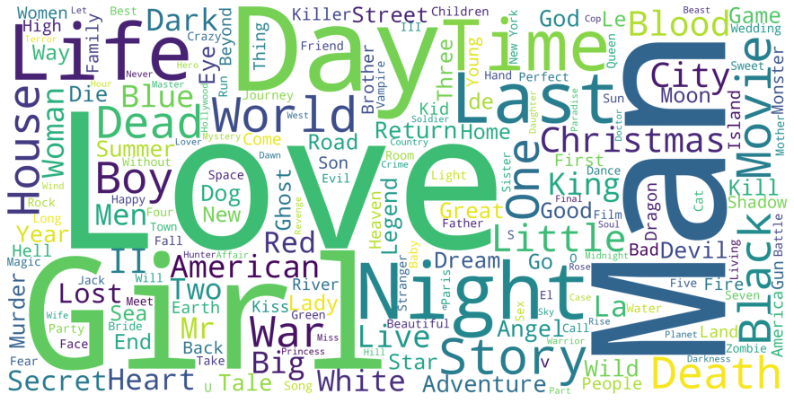

```python
plt.figure(figsize=(16,8))
plt.imshow(title_wordcloud)
plt.axis('off')
plt.show()
```

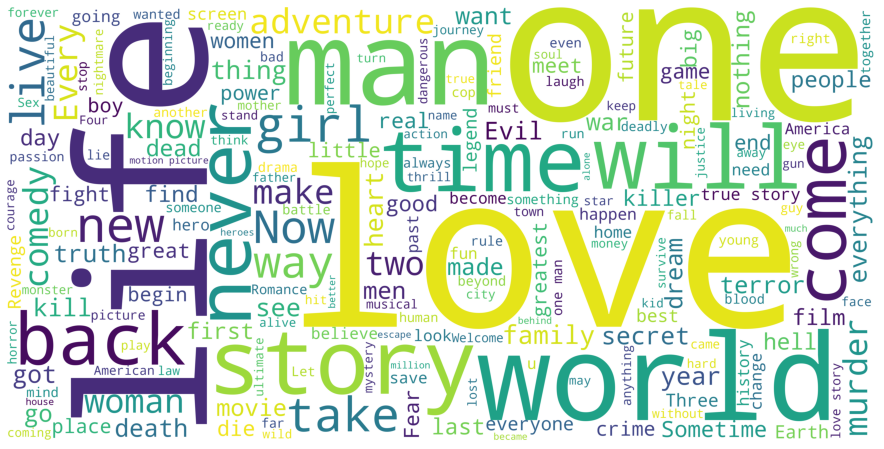

```python
tagline_wordcloud = WordCloud(background_color='white', height=2000, width=4000).generate(tagline_corpus)
plt.figure(figsize=(16,8))
plt.imshow(tagline_wordcloud)
plt.axis('off')
plt.show()
```

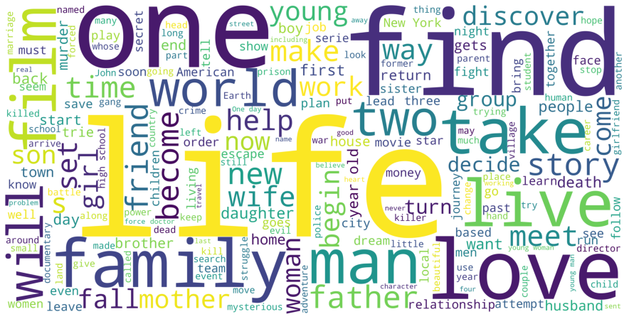

```python
overview_wordcloud = WordCloud(background_color='white', height=2000, width=4000).generate(overview_corpus)
plt.figure(figsize=(16,8))
plt.imshow(overview_wordcloud)
plt.axis('off')
plt.show()
```

## Are Franchises more successful?

```python
df.belongs_to_collection
```

```
0                  Toy Story Collection
1                                   NaN
2             Grumpy Old Men Collection
3                                   NaN
4        Father of the Bride Collection
                      ...
44686                               NaN
44687                               NaN
44688                               NaN
44689                               NaN
44690                               NaN
Name: belongs_to_collection, Length: 44691, dtype: object
```

```python
df["Franchise"] = df.belongs_to_collection.notna()
```

```python
df.Franchise.value_counts()
```

```
False    40228
True      4463
Name: Franchise, dtype: int64
```

**Franchise vs. Stand-alone: Average Revenue**

```python
df.groupby("Franchise").revenue_musd.mean()
```

```
Franchise
False    44.74
True    165.71
Name: revenue_musd, dtype: float64
```

**Franchise vs. Stand-alone: Return on Investment / Profitability**

```python
df["ROI"] = df.revenue_musd.div(df.budget_musd)
```

```python
df.groupby("Franchise").ROI.median()
```

```
Franchise
False   1.62
True    3.71
Name: ROI, dtype: float64
```

**Franchise vs. Stand-alone: Average Budget**

```python
df.groupby("Franchise").budget_musd.mean()
```

```
Franchise
False   18.05
True    38.32
Name: budget_musd, dtype: float64
```

**Franchise vs. Stand-alone: Average Popularity**

```python
df.groupby("Franchise").popularity.mean()
```

```
Franchise
False   2.59
True    6.25
Name: popularity, dtype: float64
```

**Franchise vs. Stand-alone: Average Rating**

```python
df.groupby("Franchise").vote_average.mean()
```

```
Franchise
False   6.01
True    5.96
Name: vote_average, dtype: float64
```

```python
df.groupby("Franchise").agg({"budget_musd": "mean", "revenue_musd": "mean", "vote_average": "mean",
                            "popularity": "mean", "ROI":"median", "vote_count":"mean"})
```

| Franchise | budget_musd | revenue_musd | vote_average | popularity | ROI | vote_count |
| --- | --- | --- | --- | --- | --- | --- |
| False | 18.05 | 44.74 | 6.01 | 2.59 | 1.62 | 78.29 |
| True | 38.32 | 165.71 | 5.96 | 6.25 | 3.71 | 412.39 |

## Most Successful Franchises

```python
df.belongs_to_collection.value_counts()
```

```
The Bowery Boys                  29
Totò Collection                  27
Zatôichi: The Blind Swordsman    26
James Bond Collection            26
The Carry On Collection          25
                                 ..
Salt and Pepper Collection        1
Deadpool Collection               1
Ant-Man Collection                1
Elvira Collection                 1
Red Lotus Collection              1
Name: belongs_to_collection, Length: 1691, dtype: int64
```

```python
franchises = df.groupby("belongs_to_collection").agg({"title":"count", "budget_musd": ["sum", "mean"],
                                                      "revenue_musd": ["sum", "mean"],
                                                      "vote_average": "mean", "popularity": "mean",
                                                      "ROI":"median",
                                                      "vote_count":"mean"})
```

```python
franchises
```

| belongs_to_collection | title count | budget_musd sum | budget_musd mean | revenue_musd sum | revenue_musd mean | vote_average mean | popularity mean | ROI median | vote_count mean |
| --- | --- | --- | --- | --- | --- | --- | --- | --- | --- |
| ... Has Fallen Collection | 2 | 130.00 | 65.00 | 366.78 | 183.39 | 6.00 | 13.01 | 2.86 | 2333.00 |
| 00 Schneider Filmreihe | 1 | 0.00 | NaN | 0.00 | NaN | 6.50 | 1.93 | NaN | 16.00 |
| 08/15 Collection | 1 | 0.00 | NaN | 0.00 | NaN | 5.90 | 0.63 | NaN | 4.00 |
| 100 Girls Collection | 2 | 0.00 | NaN | 0.00 | NaN | 5.15 | 3.08 | NaN | 64.00 |
| 101 Dalmatians (Animated) Collection | 2 | 4.00 | 4.00 | 215.88 | 215.88 | 6.25 | 13.06 | 53.97 | 937.00 |
| ... | ... | ... | ... | ... | ... | ... | ... | ... | ... |
| Сказки Чуковского | 1 | 0.00 | NaN | 0.00 | NaN | 3.00 | 0.73 | NaN | 3.00 |
| Чебурашка и крокодил Гена | 1 | 0.00 | NaN | 0.00 | NaN | 6.70 | 0.88 | NaN | 7.00 |
| Что Творят мужчины! (Коллекция) | 2 | 2.00 | 2.00 | 0.00 | NaN | 3.15 | 1.30 | NaN | 5.50 |
| 男はつらいよ シリーズ | 3 | 0.00 | NaN | 0.00 | NaN | 7.00 | 0.04 | NaN | 0.67 |
| 식객 시리즈 | 2 | 0.00 | NaN | 0.00 | NaN | 4.95 | 0.16 | NaN | 3.50 |

1691 rows × 9 columns

```python
franchises.nlargest(5, ("title", "count"))
```

| belongs_to_collection | title count | budget_musd sum | budget_musd mean | revenue_musd sum | revenue_musd mean | vote_average mean | popularity mean | ROI median | vote_count mean |
| --- | --- | --- | --- | --- | --- | --- | --- | --- | --- |
| The Bowery Boys | 29 | 0.00 | NaN | 0.00 | NaN | 6.67 | 0.20 | NaN | 0.72 |
| Totò Collection | 27 | 0.00 | NaN | 0.00 | NaN | 6.84 | 1.05 | NaN | 18.04 |
| James Bond Collection | 26 | 1539.65 | 59.22 | 7106.97 | 273.35 | 6.34 | 13.45 | 6.13 | 1284.31 |
| Zatôichi: The Blind Swordsman | 26 | 0.00 | NaN | 0.00 | NaN | 6.40 | 1.10 | NaN | 11.19 |
| The Carry On Collection | 25 | 0.00 | NaN | 0.00 | NaN | 6.17 | 3.22 | NaN | 21.04 |

```python
franchises.nlargest(5, ("revenue_musd", "mean"))
```

| belongs_to_collection | title count | budget_musd sum | budget_musd mean | revenue_musd sum | revenue_musd mean | vote_average mean | popularity mean | ROI median | vote_count mean |
| --- | --- | --- | --- | --- | --- | --- | --- | --- | --- |
| Avatar Collection | 1 | 237.00 | 237.00 | 2787.97 | 2787.97 | 7.20 | 185.07 | 11.76 | 12114.00 |
| The Avengers Collection | 2 | 500.00 | 250.00 | 2924.96 | 1462.48 | 7.35 | 63.63 | 5.96 | 9454.00 |
| Frozen Collection | 2 | 150.00 | 150.00 | 1274.22 | 1274.22 | 7.10 | 16.88 | 8.49 | 3035.00 |
| Finding Nemo Collection | 2 | 294.00 | 147.00 | 1968.91 | 984.45 | 7.20 | 19.99 | 7.57 | 5312.50 |
| The Hobbit Collection | 3 | 750.00 | 250.00 | 2935.52 | 978.51 | 7.23 | 25.21 | 3.83 | 5981.33 |

```python
franchises.nlargest(5, ("budget_musd", "mean"))
```

| belongs_to_collection | title count | budget_musd sum | budget_musd mean | revenue_musd sum | revenue_musd mean | vote_average mean | popularity mean | ROI median | vote_count mean |
| --- | --- | --- | --- | --- | --- | --- | --- | --- | --- |
| Tangled Collection | 2 | 260.00 | 260.00 | 591.79 | 591.79 | 7.25 | 12.32 | 2.28 | 1901.00 |
| Pirates of the Caribbean Collection | 5 | 1250.00 | 250.00 | 4521.58 | 904.32 | 6.88 | 53.97 | 3.45 | 5016.00 |
| The Avengers Collection | 2 | 500.00 | 250.00 | 2924.96 | 1462.48 | 7.35 | 63.63 | 5.96 | 9454.00 |
| The Hobbit Collection | 3 | 750.00 | 250.00 | 2935.52 | 978.51 | 7.23 | 25.21 | 3.83 | 5981.33 |
| Man of Steel Collection | 2 | 475.00 | 237.50 | 1536.11 | 768.05 | 6.10 | 24.99 | 3.22 | 6825.50 |

```python
franchises[franchises[("vote_count", "mean")] >=1000].nlargest(5, ("vote_average", "mean"))
```

| belongs_to_collection | title count | budget_musd sum | budget_musd mean | revenue_musd sum | revenue_musd mean | vote_average mean | popularity mean | ROI median | vote_count mean |
| --- | --- | --- | --- | --- | --- | --- | --- | --- | --- |
| The Lord of the Rings Collection | 3 | 266.00 | 88.67 | 2916.54 | 972.18 | 8.03 | 30.27 | 11.73 | 8253.00 |
| The Godfather Collection | 3 | 73.00 | 24.33 | 429.38 | 143.13 | 7.97 | 31.64 | 3.66 | 3677.00 |
| Blade Runner Collection | 1 | 28.00 | 28.00 | 33.14 | 33.14 | 7.90 | 96.27 | 1.18 | 3833.00 |
| The Man With No Name Collection | 3 | 2.00 | 0.67 | 35.50 | 11.83 | 7.83 | 14.17 | 25.00 | 1422.67 |
| The Dark Knight Collection | 3 | 585.00 | 195.00 | 2463.72 | 821.24 | 7.80 | 57.42 | 4.34 | 9681.00 |

## Most Successful Directors

```python
df.director.value_counts().head(5)
```

```
John Ford           66
Michael Curtiz      65
Werner Herzog       54
Alfred Hitchcock    53
Georges Méliès      49
Name: director, dtype: int64
```

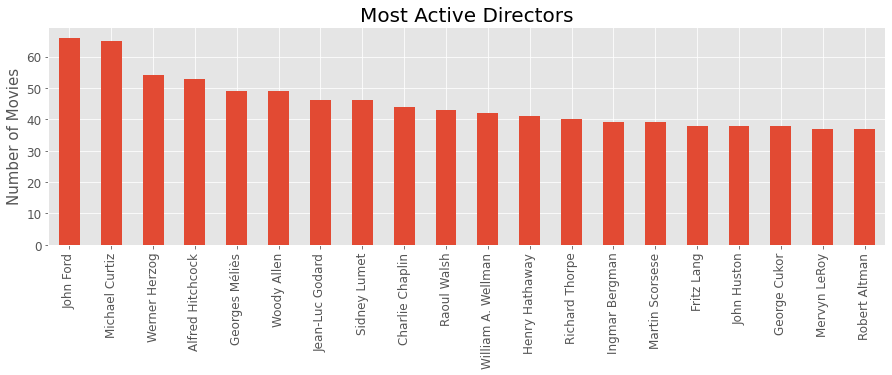

```python
plt.figure(figsize = (15, 4))
df.director.value_counts().head(20).plot(kind='bar', fontsize = 12)
plt.title("Most Active Directors",fontsize = 20)
plt.ylabel("Number of Movies", fontsize = 15)
plt.show()
```

```python
df.groupby("director").revenue_musd.sum().nlargest(10)
```

```
director
Steven Spielberg    9256.62
Peter Jackson       6528.24
Michael Bay         6437.47
James Cameron       5900.61
David Yates         5334.56
Christopher Nolan   4747.41
Robert Zemeckis     4138.23
Tim Burton          4032.92
Ridley Scott        3917.53
Chris Columbus      3866.84
Name: revenue_musd, dtype: float64
```

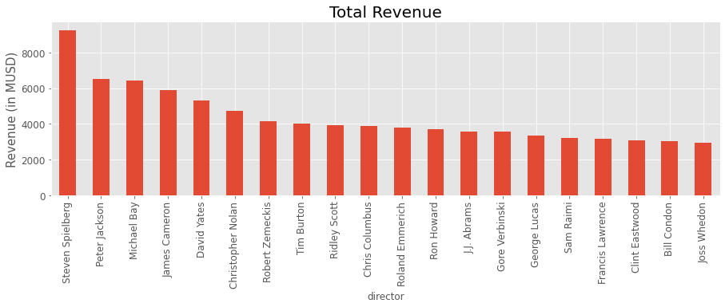

```python
plt.figure(figsize = (15, 4))
df.groupby("director").revenue_musd.sum().nlargest(20).plot(kind='bar', fontsize = 12)
plt.title("Total Revenue",fontsize = 20)
plt.ylabel("Revenue (in MUSD)", fontsize = 15)
plt.show()
```

```python
directors = df.groupby("director").agg({"title": "count", "vote_average" :"mean", "vote_count": "sum"})
```

```python
directors
```

| director | title | vote_average | vote_count |
| --- | --- | --- | --- |
| Dale Trevillion\t | 2 | 4.00 | 4.00 |
| Davide Manuli | 1 | 6.90 | 10.00 |
| E.W. Swackhamer | 1 | 5.90 | 5.00 |
| Vitaliy Vorobyov | 1 | 5.50 | 3.00 |
| Yeon Sang-Ho | 4 | 6.60 | 1039.00 |
| ... | ... | ... | ... |
| Ярополк Лапшин | 1 | 10.00 | 1.00 |
| پیمان معادی | 1 | 6.00 | 2.00 |
| 塩谷 直義 | 1 | 7.20 | 40.00 |
| 杰森·莫玛 | 1 | 5.80 | 28.00 |
| 진모영 | 1 | 6.00 | 6.00 |

17349 rows × 3 columns

```python
directors[(directors.vote_count >= 10000) & (directors.title >= 10)].nlargest(10, "vote_average")
```

| director | title | vote_average | vote_count |
| --- | --- | --- | --- |
| Hayao Miyazaki | 14 | 7.70 | 14700.00 |
| Christopher Nolan | 11 | 7.62 | 67344.00 |
| Quentin Tarantino | 10 | 7.49 | 45910.00 |
| Wes Anderson | 10 | 7.37 | 11743.00 |
| David Fincher | 10 | 7.35 | 37588.00 |
| Martin Scorsese | 39 | 7.22 | 35541.00 |
| Peter Jackson | 13 | 7.14 | 47571.00 |
| Joel Coen | 17 | 7.02 | 18139.00 |
| James Cameron | 11 | 6.93 | 33736.00 |
| Stanley Kubrick | 16 | 6.91 | 18214.00 |

```python
df.genres = df.genres.astype(str)
```

```python
df.loc[df.genres.str.contains("Horror")].groupby("director").revenue_musd.sum().nlargest(5)
```

```
director
Paul W.S. Anderson   982.29
James Wan            861.31
Wes Craven           834.93
Francis Lawrence     816.23
Ridley Scott         689.00
Name: revenue_musd, dtype: float64
```

## Most Successful Actors (Part 1)

```python
df.set_index("id", inplace = True)
```

```python
df.cast
```

```
id
862                                    Tom Hanks|Tim Allen|Don Rickles|Jim Varney|Wallace Shawn|John Ratzenberger|Annie Potts|John Morris|Erik von Detten|Laurie Metcalf|R. Lee Ermey|Sarah Freeman|Penn Jillette
8844      Robin Williams|Jonathan Hyde|Kirsten Dunst|Bradley Pierce|Bonnie Hunt|Bebe Neuwirth|David Alan Grier|Patricia Clarkson|Adam Hann-Byrd|Laura Bell Bundy|James Handy|Gillian Barber|Brandon Obray|Cyru...
15602                                                                                                              Walter Matthau|Jack Lemmon|Ann-Margret|Sophia Loren|Daryl Hannah|Burgess Meredith|Kevin Pollak
31357                                                       Whitney Houston|Angela Bassett|Loretta Devine|Lela Rochon|Gregory Hines|Dennis Haysbert|Michael Beach|Mykelti Williamson|Lamont Johnson|Wesley Snipes
11862                            Steve Martin|Diane Keaton|Martin Short|Kimberly Williams-Paisley|George Newbern|Kieran Culkin|BD Wong|Peter Michael Goetz|Kate McGregor-Stewart|Jane Adams|Eugene Levy|Lori Alan
                                                                                                           ...
439050                                                                                                                                                                    Leila Hatami|Kourosh Tahami|Elham Korda
111109                                                                     Angel Aquino|Perry Dizon|Hazel Orencio|Joel Torre|Bart Guingona|Soliman Cruz |Roeder|Angeli Bayani|Dante Perez|Betty Uy-Regala|Modesta
67758     Erika Eleniak|Adam Baldwin|Julie du Page|James Remar|Damian Chapa|Louis Mandylor|Tom Wright|Jeremy Lelliott|James Quattrochi|Jason Widener|Joe Sabatino|Kiko Ellsworth|Don Swayze|Peter Dobson|Darre...
227506                                                                                                                              Iwan Mosschuchin|Nathalie Lissenko|Pavel Pavlov|Aleksandr Chabrov|Vera Orlova
461257                                                                                                                                                                                                        NaN
Name: cast, Length: 44691, dtype: object
```

```python
act = df.cast.str.split("|", expand = True)
act
```

| id | 0 | 1 | 2 | 3 | 4 | 5 | 6 | 7 | 8 | 9 | 10 | 11 | 12 | 13 | 14 | ... | 298 | 299 | 300 | 301 | 302 | 303 | 304 | 305 | 306 | 307 | 308 | 309 | 310 | … |
| --- | --- | --- | --- | --- | --- | --- | --- | --- | --- | --- | --- | --- | --- | --- | --- | --- | --- | --- | --- | --- | --- | --- | --- | --- | --- | --- | --- | --- | --- | --- |
| 862 | Tom Hanks | Tim Allen | Don Rickles | Jim Varney | Wallace Shawn | John Ratzenberger | Annie Potts | John Morris | Erik von Detten | Laurie Metcalf | R. Lee Ermey | Sarah Freeman | Penn Jillette | None | None | ... | None | None | None | None | None | None | None | None | None | None | None | None | None | … |
| 8844 | Robin Williams | Jonathan Hyde | Kirsten Dunst | Bradley Pierce | Bonnie Hunt | Bebe Neuwirth | David Alan Grier | Patricia Clarkson | Adam Hann-Byrd | Laura Bell Bundy | James Handy | Gillian Barber | Brandon Obray | Cyrus Thiedeke | Gary Joseph Thorup | ... | None | None | None | None | None | None | None | None | None | None | None | None | None | … |
| 15602 | Walter Matthau | Jack Lemmon | Ann-Margret | Sophia Loren | Daryl Hannah | Burgess Meredith | Kevin Pollak | None | None | None | None | None | None | None | None | ... | None | None | None | None | None | None | None | None | None | None | None | None | None | … |
| 31357 | Whitney Houston | Angela Bassett | Loretta Devine | Lela Rochon | Gregory Hines | Dennis Haysbert | Michael Beach | Mykelti Williamson | Lamont Johnson | Wesley Snipes | None | None | None | None | None | ... | None | None | None | None | None | None | None | None | None | None | None | None | None | … |
| 11862 | Steve Martin | Diane Keaton | Martin Short | Kimberly Williams-Paisley | George Newbern | Kieran Culkin | BD Wong | Peter Michael Goetz | Kate McGregor-Stewart | Jane Adams | Eugene Levy | Lori Alan | None | None | None | ... | None | None | None | None | None | None | None | None | None | None | None | None | None | … |
| ... | ... | ... | ... | ... | ... | ... | ... | ... | ... | ... | ... | ... | ... | ... | ... | ... | ... | ... | ... | ... | ... | ... | ... | ... | ... | ... | ... | ... | ... | … |
| 439050 | Leila Hatami | Kourosh Tahami | Elham Korda | None | None | None | None | None | None | None | None | None | None | None | None | ... | None | None | None | None | None | None | None | None | None | None | None | None | None | … |
| 111109 | Angel Aquino | Perry Dizon | Hazel Orencio | Joel Torre | Bart Guingona | Soliman Cruz | Roeder | Angeli Bayani | Dante Perez | Betty Uy-Regala | Modesta | None | None | None | None | ... | None | None | None | None | None | None | None | None | None | None | None | None | None | … |
| 67758 | Erika Eleniak | Adam Baldwin | Julie du Page | James Remar | Damian Chapa | Louis Mandylor | Tom Wright | Jeremy Lelliott | James Quattrochi | Jason Widener | Joe Sabatino | Kiko Ellsworth | Don Swayze | Peter Dobson | Darrell Dubovsky | ... | None | None | None | None | None | None | None | None | None | None | None | None | None | … |
| 227506 | Iwan Mosschuchin | Nathalie Lissenko | Pavel Pavlov | Aleksandr Chabrov | Vera Orlova | None | None | None | None | None | None | None | None | None | None | ... | None | None | None | None | None | None | None | None | None | None | None | None | None | … |
| 461257 | NaN | NaN | NaN | NaN | NaN | NaN | NaN | NaN | NaN | NaN | NaN | NaN | NaN | NaN | NaN | ... | None | None | None | None | None | None | None | None | None | None | None | None | None | … |

44691 rows × 313 columns

```python
act = act.stack().reset_index(level=1, drop=True).to_frame()
```

```python
act.columns = ["Actor"]
```

```python
act
```

| id | Actor |
| --- | --- |
| 862 | Tom Hanks |
| 862 | Tim Allen |
| 862 | Don Rickles |
| 862 | Jim Varney |
| 862 | Wallace Shawn |
| ... | ... |
| 227506 | Iwan Mosschuchin |
| 227506 | Nathalie Lissenko |
| 227506 | Pavel Pavlov |
| 227506 | Aleksandr Chabrov |
| 227506 | Vera Orlova |

557703 rows × 1 columns

```python
act = act.merge(df[["title", "revenue_musd", "vote_average", "popularity"]],
                how = "left", left_index = True, right_index = True)
```

```python
act
```

| id | Actor | title | revenue_musd | vote_average | popularity |
| --- | --- | --- | --- | --- | --- |
| 2 | Turo Pajala | Ariel | NaN | 7.10 | 3.86 |
| 2 | Susanna Haavisto | Ariel | NaN | 7.10 | 3.86 |
| 2 | Matti Pellonpää | Ariel | NaN | 7.10 | 3.86 |
| 2 | Eetu Hilkamo | Ariel | NaN | 7.10 | 3.86 |
| 3 | Matti Pellonpää | Shadows in Paradise | NaN | 7.10 | 2.29 |
| ... | ... | ... | ... | ... | ... |
| 469172 | Vasco Sequeira | Manuel on the Island of Wonders | NaN | NaN | 0.00 |
| 469172 | Armanda Bacelar | Manuel on the Island of Wonders | NaN | NaN | 0.00 |
| 469172 | Rafael de Sousa | Manuel on the Island of Wonders | NaN | NaN | 0.00 |
| 469172 | José Antônio Gomes | Manuel on the Island of Wonders | NaN | NaN | 0.00 |
| 469172 | Isabel Branco | Manuel on the Island of Wonders | NaN | NaN | 0.00 |

557703 rows × 5 columns

## Most Successful Actors (Part 2)

```python
act.Actor.nunique()
```

```
201501
```

```python
act.Actor.unique()
```

```
array(['Turo Pajala', 'Susanna Haavisto', 'Matti Pellonpää', ...,
       'Armanda Bacelar', 'Rafael de Sousa', 'José Antônio Gomes'],
      dtype=object)
```

```python
act.Actor.value_counts().head(20)
```

```
Bess Flowers          240
Christopher Lee       148
John Wayne            125
Samuel L. Jackson     122
Michael Caine         110
Gérard Depardieu      109
John Carradine        109
Jackie Chan           108
Donald Sutherland     108
Frank Welker          107
Robert De Niro        104
Danny Trejo           101
Steve Buscemi         101
Irving Bacon           98
John Goodman           97
Christopher Walken     96
Danny Glover           95
John Hurt              93
Susan Sarandon         92
Dennis Hopper          92
Name: Actor, dtype: int64
```

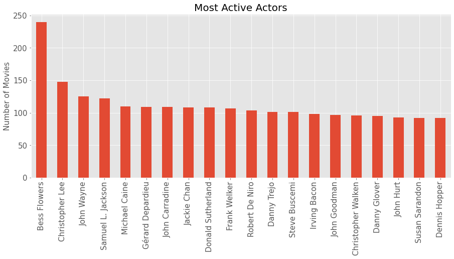

```python
plt.figure(figsize = (15, 6))
act.Actor.value_counts().head(20).plot(kind='bar', fontsize = 15)
plt.title("Most Active Actors",fontsize = 20)
plt.ylabel("Number of Movies", fontsize = 15)
plt.show()
```

```python
agg = act.groupby("Actor").agg(Total_Revenue = ("revenue_musd", "sum"),
                               Mean_Revenue = ("revenue_musd", "mean"),
                               Mean_Rating = ("vote_average", "mean"),
                               Mean_Pop = ("popularity", "mean"),
                               Total_Movies = ("Actor", "count"))
```

```python
agg.nlargest(10, "Total_Movies")
```

| Actor | Total_Revenue | Mean_Revenue | Mean_Rating | Mean_Pop | Total_Movies |
| --- | --- | --- | --- | --- | --- |
| Bess Flowers | 368.91 | 14.76 | 6.18 | 2.03 | 240 |
| Christopher Lee | 9417.05 | 324.73 | 5.91 | 4.75 | 148 |
| John Wayne | 236.09 | 11.24 | 5.71 | 3.09 | 125 |
| Samuel L. Jackson | 17109.62 | 213.87 | 6.27 | 11.70 | 122 |
| Michael Caine | 8053.40 | 191.75 | 6.27 | 8.27 | 110 |
| Gérard Depardieu | 1247.61 | 95.97 | 6.05 | 3.70 | 109 |
| John Carradine | 255.84 | 19.68 | 5.55 | 2.43 | 109 |
| Donald Sutherland | 5390.77 | 138.22 | 6.23 | 7.00 | 108 |
| Jackie Chan | 4699.19 | 146.85 | 6.28 | 5.86 | 108 |
| Frank Welker | 13044.15 | 326.10 | 6.31 | 9.57 | 107 |

```python
agg.nlargest(10, "Total_Revenue")
```

| Actor | Total_Revenue | Mean_Revenue | Mean_Rating | Mean_Pop | Total_Movies |
| --- | --- | --- | --- | --- | --- |
| Stan Lee | 19414.96 | 647.17 | 6.51 | 29.94 | 48 |
| Samuel L. Jackson | 17109.62 | 213.87 | 6.27 | 11.70 | 122 |
| Warwick Davis | 13256.03 | 662.80 | 6.29 | 13.09 | 34 |
| Frank Welker | 13044.15 | 326.10 | 6.31 | 9.57 | 107 |
| John Ratzenberger | 12596.13 | 449.86 | 6.48 | 10.96 | 46 |
| Jess Harnell | 12234.61 | 611.73 | 6.44 | 10.92 | 35 |
| Hugo Weaving | 11027.58 | 459.48 | 6.47 | 10.97 | 40 |
| Ian McKellen | 11015.59 | 478.94 | 6.35 | 15.45 | 44 |
| Johnny Depp | 10653.76 | 217.42 | 6.44 | 12.38 | 69 |
| Alan Rickman | 10612.63 | 353.75 | 6.72 | 10.40 | 45 |

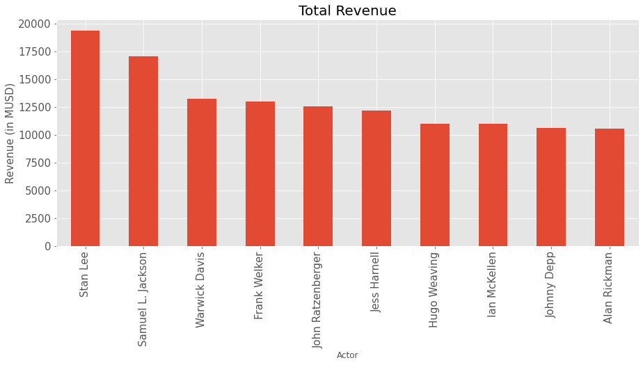

```python
plt.figure(figsize = (15, 6))
agg.Total_Revenue.nlargest(10).plot(kind='bar', fontsize = 15)
plt.title("Total Revenue",fontsize = 20)
plt.ylabel("Revenue (in MUSD)", fontsize = 15)
plt.show()
```

```python
agg.Mean_Revenue.nlargest(10)
```

```
Actor
April Marie Thomas   2787.97
Ashley Jeffery       2787.97
Austin Wilson        2787.97
Brandon Jelkes       2787.97
Bravita A. Threatt   2787.97
Carvon Futrell       2787.97
Chris Mala           2787.97
Christa Oliver       2787.97
Christopher Nolen    2787.97
Colin Bleasdale      2787.97
Name: Mean_Revenue, dtype: float64
```

```python
agg[agg.Total_Movies >= 10].nlargest(10, "Mean_Revenue")
```

| Actor | Total_Revenue | Mean_Revenue | Mean_Rating | Mean_Pop | Total_Movies |
| --- | --- | --- | --- | --- | --- |
| Gloria Stuart | 1845.03 | 1845.03 | 6.37 | 3.48 | 18 |
| Keith Richards | 2967.71 | 989.24 | 6.46 | 5.03 | 23 |
| Zoë Wanamaker | 976.48 | 976.48 | 6.33 | 6.82 | 10 |
| James Cameron | 1862.08 | 931.04 | 7.06 | 4.69 | 12 |
| Matthew Lewis | 7915.31 | 879.48 | 7.37 | 23.10 | 11 |
| Luke de Woolfson | 1720.67 | 860.34 | 5.72 | 8.77 | 11 |
| Yuri Lowenthal | 1708.16 | 854.08 | 6.19 | 19.88 | 17 |
| Dominic Monaghan | 3289.61 | 822.40 | 6.05 | 10.62 | 11 |
| Philip Ng | 821.71 | 821.71 | 5.92 | 6.35 | 10 |
| Peter Mayhew | 4820.72 | 803.45 | 6.70 | 12.30 | 11 |

```python
agg[agg.Total_Movies >= 10].nlargest(10, "Mean_Rating")
```

| Actor | Total_Revenue | Mean_Revenue | Mean_Rating | Mean_Pop | Total_Movies |
| --- | --- | --- | --- | --- | --- |
| Masao Hayama | 0.00 | NaN | 8.84 | 0.32 | 10 |
| David Attenborough | 0.00 | NaN | 8.27 | 2.15 | 11 |
| Emil Jannings | 0.00 | NaN | 7.78 | 1.70 | 10 |
| Halit Akçatepe | 0.21 | 0.21 | 7.78 | 0.74 | 10 |
| Yo Oizumi | 511.21 | 102.24 | 7.72 | 7.51 | 13 |
| Şener Şen | 11.07 | 3.69 | 7.69 | 0.91 | 16 |
| Ayşen Gruda | 0.91 | 0.46 | 7.68 | 0.74 | 10 |
| Akira Tani | 0.33 | 0.16 | 7.65 | 5.04 | 12 |
| Joseph Oliveira | 3543.44 | 354.34 | 7.64 | 34.45 | 10 |
| Björk | 51.33 | 25.67 | 7.62 | 2.36 | 10 |

```python
agg[agg.Total_Movies >= 10].nlargest(10, "Mean_Pop")
```

| Actor | Total_Revenue | Mean_Revenue | Mean_Rating | Mean_Pop | Total_Movies |
| --- | --- | --- | --- | --- | --- |
| Katy Mixon | 1519.57 | 151.96 | 5.84 | 51.97 | 12 |
| Terry Notary | 6947.21 | 694.72 | 6.47 | 51.58 | 11 |
| Goran D. Kleut | 2568.94 | 366.99 | 6.00 | 42.32 | 10 |
| Mark Smith | 2195.52 | 243.95 | 6.55 | 40.08 | 11 |
| Jon Hamm | 3449.35 | 191.63 | 6.33 | 39.42 | 25 |
| Gal Gadot | 5449.53 | 495.41 | 6.33 | 37.39 | 11 |
| Ava Acres | 6272.36 | 482.49 | 5.99 | 36.26 | 21 |
| Emma Watson | 9639.20 | 535.51 | 6.77 | 35.97 | 19 |
| Joseph Oliveira | 3543.44 | 354.34 | 7.64 | 34.45 | 10 |
| Keith Jardine | 1062.49 | 212.50 | 5.96 | 32.00 | 11 |